# Series02-Rstudio :

Camille JAFFEUX

08 October, 2025, 13:39

# 1 Correlations and linear regression

In this series of exercises, you will explore correlations and linear regression, using a dataset from a real experiment.

## 1.1 The problem

You want to know if there is a relationship between the nonuse of the proximal part of the upper limb (PANU) and the nonuse of the shoulder (SANU) or the elbow (EENU).

## 1.2 The data

As you will see, the data is far from perfect, but this is the reality of experimental data, especially in the case of clinical data.

Download the file NonUse.csv from the course Moodle.

```r
nonuse <- read.csv("data/NonUse.csv", sep=",", header=TRUE)
head(nonuse)
```

|  | PANU | EENU | SANU |
| --- | --- | --- | --- |
| 1 | -1.91808 | 5.361647 | -4.838554 |
| 2 | 1.12289 | -2.505418 | 1.737964 |
| 3 | 1.84061 | 5.952974 | -1.442610 |
| 4 | 0.07064 | 4.038350 | -1.670562 |
| 5 | 3.15233 | NA | NA |
| 6 | 1.86301 | NA | NA |

```r
summary(nonuse)
```

```
##       PANU             EENU               SANU
##  Min.   :-3.306   Min.   :-33.9780   Min.   :-38.4178
##  1st Qu.: 1.629   1st Qu.: -0.4864   1st Qu.: -3.4968
##  Median : 4.370   Median :  6.2732   Median :  0.9708
##  Mean   : 9.742   Mean   :  8.3701   Mean   :  1.3908
##  3rd Qu.:13.919   3rd Qu.: 15.3383   3rd Qu.:  7.0470
##  Max.   :68.286   Max.   : 50.1748   Max.   : 40.1735
##  NA's   :13       NA's   :223        NA's   :223
```

This file contains measures of upper extremity nonuse:

```
    -PANU: Proximal Arm Non Use
    -SANU: Shoulder Antepulsion Non Use
    -EENU: Elbow Extension Non Use
```

In your notebook, make a clear description of the experiment, the variables and the data. Do not forget to give the units of each variable, and the range of possible values.

[output not shown]

## 1.3 Corelation analysis

Below are some questions to guide your analysis.

Is PANU correlated with SANU and/or EENU?

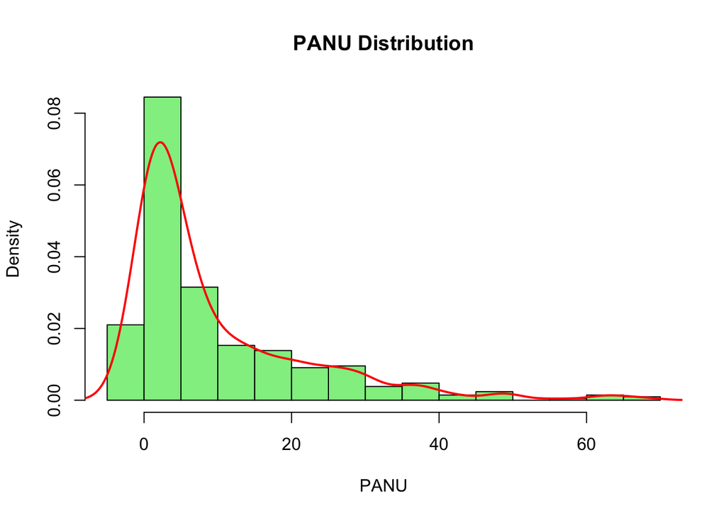

```r
hist(nonuse$PANU,
     main = "PANU Distribution",
     xlab = "PANU",
     col = "lightgreen",
     border = "black",
     breaks = 20,       # number of bins
     probability = TRUE) # scales y-axis as density

# Add density curve
lines(density(nonuse$PANU, na.rm = TRUE),
      col = "red", lwd = 2)
```

```r
cor.test(nonuse$PANU, nonuse$SANU, method = "spearman")
```

```
##
##  Spearman's rank correlation rho
##
## data:  nonuse$PANU and nonuse$SANU
## S = 1192838, p-value = 0.001718
## alternative hypothesis: true rho is not equal to 0
## sample estimates:
##       rho
## 0.2160221
```

Visualize the PANU-SANU relationship (and the PANU-EENU relationship)

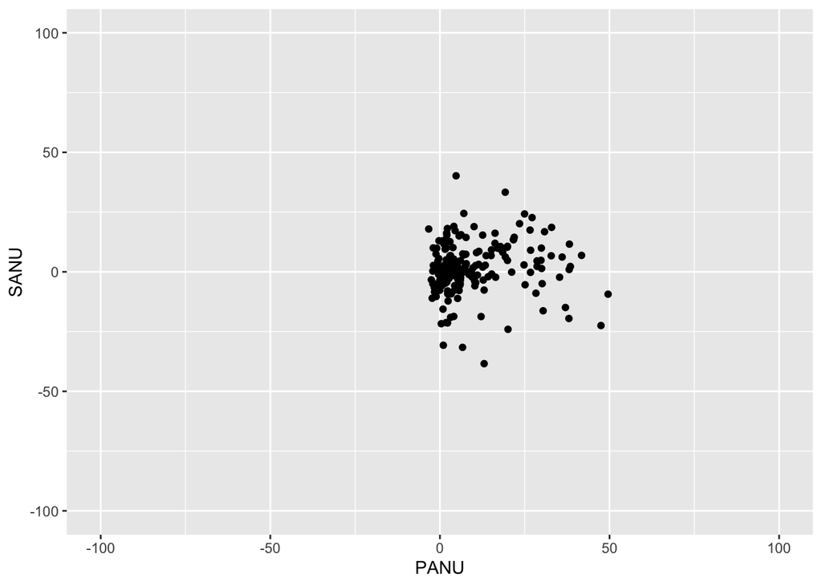

```r
library(ggplot2)
ggplot(nonuse, aes(x=PANU, y=SANU)) +
  geom_point() +
  xlim(-100, 100) +
  ylim(-100, 100)
```